# hab2

Lukáš Hejtmánek

Wed Jul 08 18:55:11 2020

## Summative heatmaps

### females

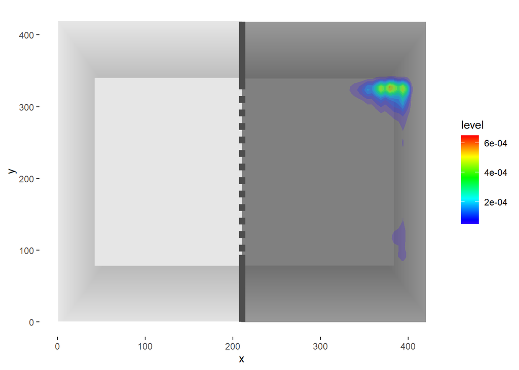

### males

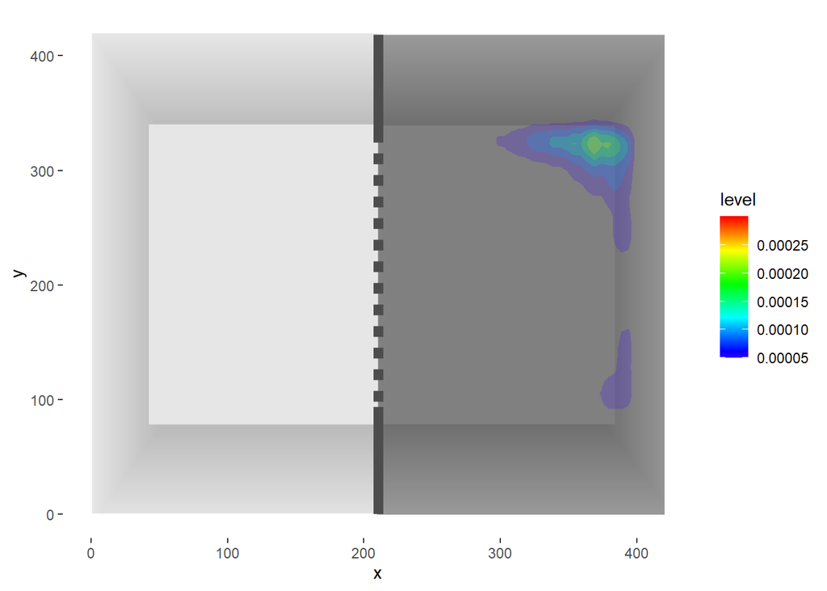

### Individual animals

animal_1

Animal:

animal_1

Distance:

21519.07

Time in left zone:

24.87

Time in right zone:

867.1

Time in central zone:

2.79

Crosses to the right:

1

Crosses to the left:

1

Number of freezes:

16

Total freeze time:

189.71

Freeze time ratio:

0.21

Animal:

animal_1

Distance:

25501.19

Time in left zone:

NA

Time in right zone:

899.63

Time in central zone:

NA

Crosses to the right:

0

Crosses to the left:

0

Number of freezes:

9

Total freeze time:

44.46

Freeze time ratio:

0.05

animal_10

Animal:

animal_10

Distance:

22219.82

Time in left zone:

NA

Time in right zone:

899.61

Time in central zone:

NA

Crosses to the right:

0

Crosses to the left:

0

Number of freezes:

23

Total freeze time:

128.05

Freeze time ratio:

0.14

Animal:

animal_10

Distance:

11219.21

Time in left zone:

NA

Time in right zone:

899.59

Time in central zone:

NA

Crosses to the right:

0

Crosses to the left:

0

Number of freezes:

21

Total freeze time:

251.99

Freeze time ratio:

0.28

animal_2

Animal:

animal_2

Distance:

5620.97

Time in left zone:

NA

Time in right zone:

898.76

Time in central zone:

NA

Crosses to the right:

0

Crosses to the left:

0

Number of freezes:

18

Total freeze time:

580.5

Freeze time ratio:

0.65

Animal:

animal_2

Distance:

17460.67

Time in left zone:

NA

Time in right zone:

888.08

Time in central zone:

NA

Crosses to the right:

0

Crosses to the left:

0

Number of freezes:

15

Total freeze time:

182.36

Freeze time ratio:

0.21

animal_3

Animal:

animal_3

Distance:

14968.44

Time in left zone:

NA

Time in right zone:

884.59

Time in central zone:

NA

Crosses to the right:

0

Crosses to the left:

0

Number of freezes:

17

Total freeze time:

312.38

Freeze time ratio:

0.35

Animal:

animal_3

Distance:

13252.51

Time in left zone:

NA

Time in right zone:

897.72

Time in central zone:

NA

Crosses to the right:

0

Crosses to the left:

0

Number of freezes:

22

Total freeze time:

302.4

Freeze time ratio:

0.34

animal_4

Animal:

animal_4

Distance:

17164.46

Time in left zone:

NA

Time in right zone:

895.67

Time in central zone:

NA

Crosses to the right:

0

Crosses to the left:

0

Number of freezes:

20

Total freeze time:

226.8

Freeze time ratio:

0.25

Animal:

animal_4

Distance:

24124.56

Time in left zone:

NA

Time in right zone:

898.72

Time in central zone:

NA

Crosses to the right:

0

Crosses to the left:

0

Number of freezes:

9

Total freeze time:

44.49

Freeze time ratio:

0.05

animal_5

Animal:

animal_5

Distance:

19001.7

Time in left zone:

NA

Time in right zone:

884.58

Time in central zone:

NA

Crosses to the right:

0

Crosses to the left:

0

Number of freezes:

17

Total freeze time:

217.42

Freeze time ratio:

0.25

Animal:

animal_5

Distance:

17635.39

Time in left zone:

NA

Time in right zone:

899.02

Time in central zone:

NA

Crosses to the right:

0

Crosses to the left:

0

Number of freezes:

14

Total freeze time:

164.07

Freeze time ratio:

0.18

animal_6

Animal:

animal_6

Distance:

15875.75

Time in left zone:

NA

Time in right zone:

892.94

Time in central zone:

NA

Crosses to the right:

0

Crosses to the left:

0

Number of freezes:

27

Total freeze time:

198.46

Freeze time ratio:

0.22

Animal:

animal_6

Distance:

14745.7

Time in left zone:

NA

Time in right zone:

899.63

Time in central zone:

NA

Crosses to the right:

0

Crosses to the left:

0

Number of freezes:

23

Total freeze time:

271.25

Freeze time ratio:

0.3

animal_7

Animal:

animal_7

Distance:

24265.83

Time in left zone:

NA

Time in right zone:

898.63

Time in central zone:

NA

Crosses to the right:

0

Crosses to the left:

0

Number of freezes:

23

Total freeze time:

131.26

Freeze time ratio:

0.15

Animal:

animal_7

Distance:

18501.33

Time in left zone:

NA

Time in right zone:

870.49

Time in central zone:

NA

Crosses to the right:

0

Crosses to the left:

0

Number of freezes:

10

Total freeze time:

109.2

Freeze time ratio:

0.13

animal_8

Animal:

animal_8

Distance:

18839.04

Time in left zone:

NA

Time in right zone:

894.88

Time in central zone:

NA

Crosses to the right:

0

Crosses to the left:

0

Number of freezes:

18

Total freeze time:

164.63

Freeze time ratio:

0.18

Animal:

animal_8

Distance:

17216.88

Time in left zone:

NA

Time in right zone:

899.21

Time in central zone:

NA

Crosses to the right:

0

Crosses to the left:

0

Number of freezes:

16

Total freeze time:

164.07

Freeze time ratio:

0.18

animal_9

Animal:

animal_9

Distance:

16845.12

Time in left zone:

NA

Time in right zone:

895.78

Time in central zone:

NA

Crosses to the right:

0

Crosses to the left:

0

Number of freezes:

20

Total freeze time:

134.11

Freeze time ratio:

0.15

Animal:

animal_9

Distance:

11527.61

Time in left zone:

NA

Time in right zone:

889.5

Time in central zone:

NA

Crosses to the right:

0

Crosses to the left:

0

Number of freezes:

28

Total freeze time:

322.79

Freeze time ratio:

0.36

## Summary statistics

#### females

Animal:

Distance:

17632.02

Time in left zone:

24.87

Time in right zone:

891.25

Time in central zone:

2.79

Crosses to the right:

0.1

Crosses to the left:

0.1

Number of freezes:

19.9

Total freeze time:

228.33

Freeze time ratio:

0.26

#### males

Animal:

Distance:

17118.51

Time in left zone:

NaN

Time in right zone:

894.16

Time in central zone:

NaN

Crosses to the right:

0

Crosses to the left:

0

Number of freezes:

16.7

Total freeze time:

185.71

Freeze time ratio:

0.21